# EDA

Chun Su

2/10/2020

# 1. data cleaning

I further clean the data based on what Mitch has done so far, specifically focusin on

- remove space within columns os that it is easy to access by auto-fill.
- convert latitude and logtitude info to estimated address and zipcode using `ggmap`.
- (for R user only) convert IncidentDate to date class.

```r
library(tidyverse)
library(lubridate)
# Mitch initial cleanup
OD_info <- read_csv("data/Overdose_Information_Network_Data_CY_January_2018_-_Current_Monthly_County_State_Police.csv")

OD_unique <- OD_info %>%
  dplyr::select(
    `Incident ID`:`Victim County`, `Incident County FIPS Code`:`Victim County Latitude and Longitude`, `Naloxone Administered`, `Response Time Desc`,
    Survive
  ) %>%
  distinct()

OD_drug <- OD_info %>%
  dplyr::select(`Accidental Exposure`:`Susp OD Drug Desc`, `Incident ID`, `Victim ID`) %>%
  distinct() %>%
  mutate(tmp = 1) %>%
  pivot_wider(id_cols = c(`Incident ID`, `Victim ID`), values_from = tmp, values_fill = list(tmp = 0), names_from = `Susp OD Drug Desc`)

OD_all <- inner_join(OD_unique,OD_drug)

# rename columan to remove space
colnames(OD_all) <- gsub(" ", "",colnames(OD_all))

# remove redundant columns
OD_all <- OD_all %>% select(-IncidentCountyLatitudeandLongitude, -VictimCountyLatitudeandLongitude)

# convert longitude and latitude info to address
# register_google(key = <API_key>) # get API_key from https://console.cloud.google.com/apis/credentials
lon_lat_to_address <- function(lat, lon){
        res <- revgeocode(c(lon,lat), output="address")
        res
}

OD_all <- OD_all %>%
        mutate(IncidentEstimatedAddress=mapply(lon_lat_to_address,IncidentCountyLatitude, IncidentCountyLongitude)) %>%
        mutate(VictimEstimatedAddress=mapply(lon_lat_to_address,VictimCountyLatitude, VictimCountyLongitude))
address="1307 E Baltimore Pike, Media, PA 19063, USA"

# convert address to zipcode
address2zipcode <- function(address){
        if (is.na(address)){
                zipcode=NA
        }else{
                tmp = strsplit(address, ",")[[1]]
                zipcode=tmp[length(tmp)-1]
                zipcode=gsub("PA","",zipcode)
                zipcode=gsub(" ","",zipcode)
        }
        zipcode

}

OD_all = OD_all %>%
        mutate(IncidentZipcode=sapply(IncidentEstimatedAddress,address2zipcode))

OD_all = OD_all %>%
        mutate(VictimZipcode=sapply(VictimEstimatedAddress,address2zipcode))

OD_all %>% select(contains("Zipcode"))

# convert date
OD_all <- OD_all %>%
        mutate(IncidentDate=parse_date(IncidentDate, "%m/%d/%y"))

# save R object and csv
save(OD_all, file="data/OD_all_processedCS.Rdata")
write_csv(
        OD_all,
        path="data/OD_all_processedCS.csv"
)
```

# 2. EDA on county

Generally, this date include the 10774 incident reports from 2018-01-01 to 2020-01-15 involving 10953 victims from 67 counties from Pennsylvania. Those victims include 7516 males and 3412 females (25 unknown), with majority age range from 20 to 49 (which contributes to 86% victims) and age range 30 - 39 have highest number of victim. 7236 (66.06%) of those victims have been administered with Naloxone and 8471 (77.3%) survived.

To carefully investigate the age range rate, gender rate, NaloxoneAdministered rate, Survive rate within Philadephia and outside of Philadephia, I grouped the victims to IncidentCounty.

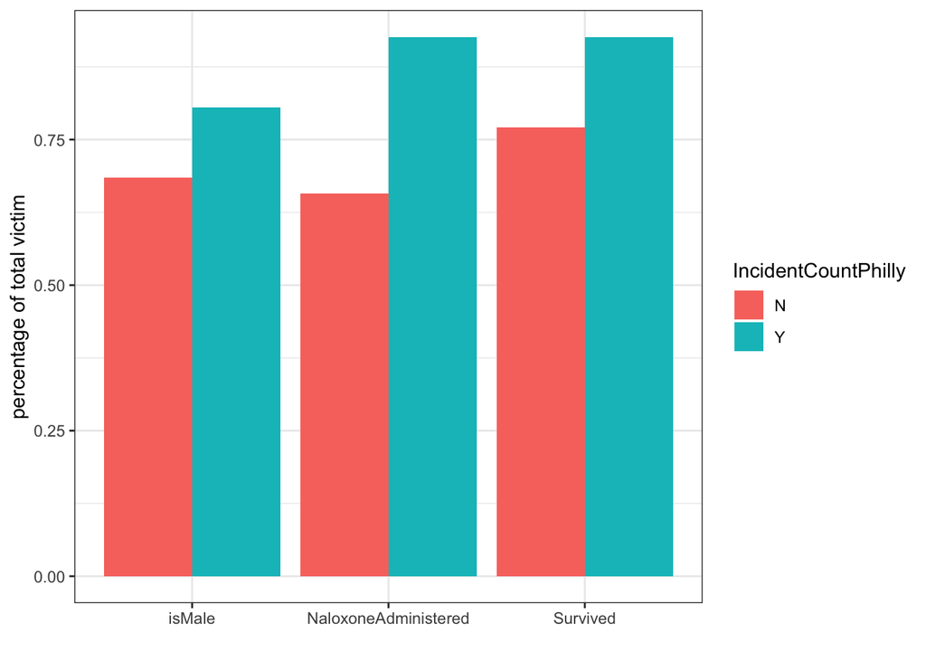

```r
df = OD_all %>%
        mutate(IncidentCountPhilly=ifelse(IncidentCountyName=="Philadelphia", "Y","N")) %>%
        group_by(IncidentCountPhilly, GenderDesc, NaloxoneAdministered, Survive, AgeRange) %>%
        summarise(victim_n = n_distinct(VictimID)) %>%
        ungroup()


# gender ratio
df1 = left_join(
        df %>% group_by(IncidentCountPhilly, GenderDesc) %>%
                summarise(victim_n=sum(victim_n)) %>%
                ungroup(),
        df %>% group_by(IncidentCountPhilly) %>%
                summarise(total=sum(victim_n)) %>%
                ungroup()
)


df1 = df1 %>% filter(GenderDesc=="Male") %>%
        mutate(isMale=victim_n/total) %>%
        select(IncidentCountPhilly, isMale)

# NaloxoneAdministered rate
df2 = left_join(
        df %>% group_by(IncidentCountPhilly, NaloxoneAdministered) %>%
                summarise(victim_n=sum(victim_n)) %>%
                ungroup(),
        df %>% group_by(IncidentCountPhilly) %>%
                summarise(total=sum(victim_n)) %>%
                ungroup()
)

df2 = df2 %>% filter(NaloxoneAdministered=="Y") %>%
        mutate(NaloxoneAdministered=victim_n/total) %>%
        select(IncidentCountPhilly, NaloxoneAdministered)

# Survive rate
df3 = left_join(
        df %>% group_by(IncidentCountPhilly, Survive) %>%
                summarise(victim_n=sum(victim_n)) %>%
                ungroup(),
        df %>% group_by(IncidentCountPhilly) %>%
                summarise(total=sum(victim_n)) %>%
                ungroup()
)

df3 = df3 %>% filter(Survive=="Y") %>%
        mutate(Survived=victim_n/total) %>%
        select(IncidentCountPhilly, Survived)

df_ratio = bind_rows(
        df1 %>% mutate(type="isMale") %>% dplyr::rename(ratio=isMale),
        df2 %>% mutate(type="NaloxoneAdministered") %>% dplyr::rename(ratio=NaloxoneAdministered),
        df3 %>% mutate(type="Survived") %>% dplyr::rename(ratio=Survived)
)

ggplot(df_ratio, aes(x=type, y=ratio, fill=IncidentCountPhilly)) +
        geom_col(position="dodge") +
        theme_bw() +
        xlab("") +
        ylab("percentage of total victim")
```

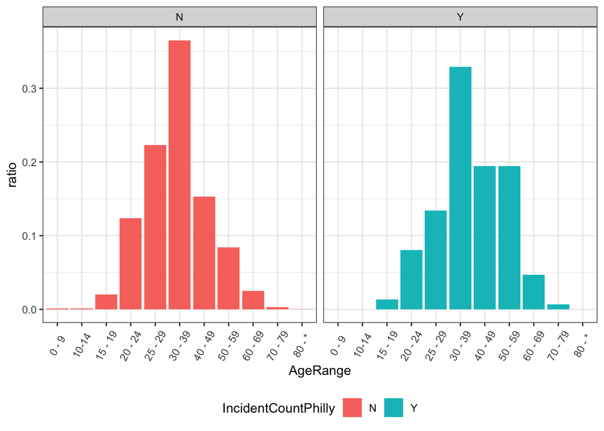

```r
# age range rate
df4 = left_join(
        df %>% group_by(IncidentCountPhilly, AgeRange) %>%
                summarise(victim_n=sum(victim_n)) %>%
                ungroup(),
        df %>% group_by(IncidentCountPhilly) %>%
                summarise(total=sum(victim_n)) %>%
                ungroup()
)

df4 = df4 %>% mutate(ratio=victim_n/total)
df4 = df4 %>% mutate(AgeRange=ifelse(AgeRange=="14-Oct","10-14",AgeRange))
ggplot(df4, aes(x=AgeRange, y=ratio, fill=IncidentCountPhilly)) +
        facet_wrap(~IncidentCountPhilly) +
        geom_col(position = "dodge") +
        theme_bw() +
        theme(legend.position = "bottom",
              axis.text.x = element_text(angle=60, vjust = 0.5))
```

Philadelphia, where Prevention Point is located, have higher ratio of victim who have been administered with Narcan before and higher survival rate of overdose. However, high survival rate may not be directly associated with Narcan administrated rate. There are victim population structure (age, gender) difference between Philly and other PA counties too.